# First Day: Playing in R

## Basic Math

```r
4 + 6
```

```
## [1] 10
```

```r
(3 + 5)^2/17 + 21
```

```
## [1] 24.76471
```

Parentheses matter!

```r
(3 + 5)^2/(17 + 21)
```

```
## [1] 1.684211
```

## Creating Data

```r
correct <- c(8, 6, 5, 8, 7, 8, 9, 6, 10, 8)

correct
```

```
##  [1]  8  6  5  8  7  8  9  6 10  8
```

### What is in our environment?

```r
ls()
```

```
## [1] "correct"
```

## Using and Importing Datasets

```r
data1 <- c(45, 56, 34, 56, 25, 74, 35, 68, 98, 56)

data2 <- c(7, 5, 3, 6, 4, 7, 6, 4, 5, 9)
```

### What is in our environment now?

```r
ls()
```

```
## [1] "correct" "data1"   "data2"
```

### Removing an object from the workspace

```r
rm(data2)
```

### What is in our environment now?

```r
ls()
```

```
## [1] "correct" "data1"
```

### See the contents of an object

To see the contents of an object, enter the name of the object.

```r
data1
```

```
##  [1] 45 56 34 56 25 74 35 68 98 56
```

### Importing Existing Data

Importing datafiles (.csv’s) follows the following format:

`example <- read.csv("file_name.csv", header = TRUE)`

**example** = the object name you want RStudio to assign the object in R

**<- read.csv()** = tells RStudio to read a .csv file.

**file_name.csv** = the name of the datafile you will be reading into R. R is CASE SENSITIVE.

**header = TRUE** = tells RStudio that the .csv table has column names in the first row of the file that it can use to label the variables.

```r
example <- read.csv("Data/SampleDataSet.csv", header = TRUE)
```

### Preview the data

**head()** lets you look at the first 6 rows of data

```r
head(example)
```

```
##   ID Gender    Treatment Test1 Test2
## 1  1   Male      Control    98    32
## 2  2 Female Experimental    87    33
## 3  3 Female      Control    89    54
## 4  4 Female      Control    88    44
## 5  5   Male Experimental    76    64
## 6  6   Male      Control    68    54
```

**names()** tells you the variable names

```r
names(example)
```

```
## [1] "ID"        "Gender"    "Treatment" "Test1"     "Test2"
```

**$** allows you to index specific variables. For example, if I want to look at the `Test1` variable I would:

```r
example$Test1
```

```
##  [1] 98 87 89 88 76 68 78 98 93 76 75 65 76 78 89 81 78 83 88 90 93 89 86 77 89
```

**summary()** will let us get some basic descriptive statistics of our dataset.

```r
summary(example)
```

```
##        ID        Gender           Treatment             Test1
##  Min.   : 1   Length:25          Length:25          Min.   :65.00
##  1st Qu.: 7   Class :character   Class :character   1st Qu.:77.00
##  Median :13   Mode  :character   Mode  :character   Median :86.00
##  Mean   :13                                         Mean   :83.52
##  3rd Qu.:19                                         3rd Qu.:89.00
##  Max.   :25                                         Max.   :98.00
##      Test2
##  Min.   :32.00
##  1st Qu.:44.00
##  Median :64.00
##  Mean   :64.24
##  3rd Qu.:81.00
##  Max.   :99.00
```

## Libraries

Libraries are external sources of code that we can load into R. There are THOUSANDS of libraries we can use. Everytime we want to use certain functions, we load in a specific library. There are a lot of really nice people who have taken the time to write TONS of code to save us time. We will primarily be using the following: *ggplot2, psych, tidyverse*.

```r
library(ggplot2)
library(psych)
library(tidyverse)
```

## GGPLOT2

GGPLOT is a powerful package for data visualizations. Whenever you want to make graphs, you will need to load ggplot2.

### Scatterplot

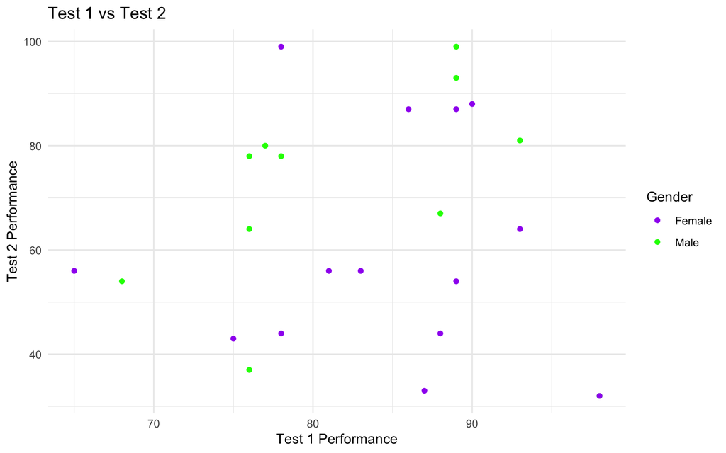

```r
ggplot(example, aes(x = Test1, y = Test2, color = Gender)) +
  geom_point() +
  theme_minimal() +
  labs(x = "Test 1 Performance",
       y = "Test 2 Performance",
       title = "Test 1 vs Test 2") +
  scale_color_manual(values = c("purple", "green"))
```

### Barplot

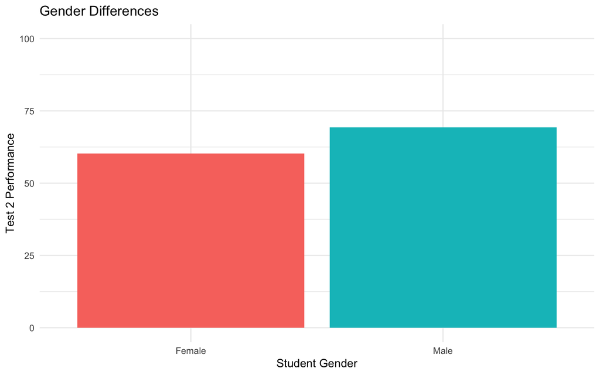

```r
ggplot(example, aes(x = Gender, y = Test2, fill = Gender)) +
  stat_summary(fun = "mean", geom = "bar") +
  theme_minimal() +
  labs(x = "Student Gender", y = "Test 2 Performance", title = "Gender Differences") +
  ylim(0,100) +
  guides(fill = "none")
```

## Install New Packages

https://github.com/BlakeRMills/MetBrewer

Installing packages only needs to be done ONCE. That is why I have added a “#” to be able to show the code but not run it again.

```r
#install.packages("MetBrewer")
library(MetBrewer)
MetBrewer::colorblind_palettes
```

```
##  [1] "Cassatt1"    "Cassatt2"    "Derain"      "Egypt"       "Greek"
##  [6] "Hiroshige"   "Hokusai2"    "Hokusai3"    "Ingres"      "Isfahan1"
## [11] "Isfahan2"    "Morgenstern" "OKeeffe1"    "OKeeffe2"    "Pillement"
## [16] "Troy"        "VanGogh3"    "Veronese"
```

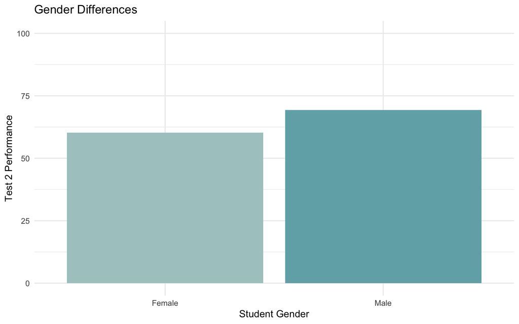

```r
ggplot(example, aes(x = Gender, y = Test2, fill = Gender)) +
  stat_summary(fun = "mean", geom = "bar") +
  theme_minimal() +
  labs(x = "Student Gender", y = "Test 2 Performance", title = "Gender Differences") +
  ylim(0,100) +
  guides(fill = "none") +
  scale_fill_manual(values=met.brewer("Hokusai2"))
```

Don’t forget….knit often!